# Chromosome compaction - simple three-state model

# 11/08/2017

Fitting scramble once again, with $\Delta t_2 = 0$, but with very large `nsim` and `ntry`. This should be our reference fit. And it will take forever to calculate.

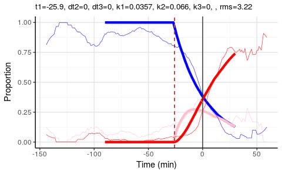

```r
pars <- c3pars()
free <- c("t1", "k1", "k2")
chr.scr <- cacheData("fit_scramble_n10000.50_t1_k1_k2", fitChr, echr.scr, pars, free, nsim=10000, ntry=50, ncores=6, binDir=binDir)
plotTimelines(chr.scr, expdata = echr.scr, withpars=TRUE)
```

## NCAPD2

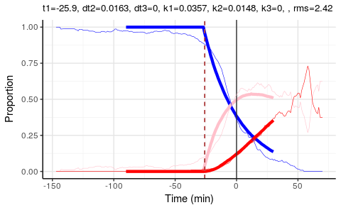

```r
pars <- chr.scr$pars
free <- c("k2", "dt2")
chr.d2.2 <- cacheData("fit_NCAPD2_n10000_k2_dt2", fitChr, echr.d2, pars, free, nsim=10000, ntry=50, ncores=6, binDir=binDir)
plotTimelines(chr.d2.2, expdata = echr.d2, withpars=TRUE)
```

Tiny differences in comparison to other NCAPD2 fits. Most likely negligible.

## NCAPD3

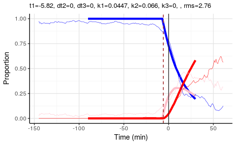

```r
pars <- chr.scr$pars
free <- c("k1", "t1")
chr.d3.2 <- cacheData("fit_NCAPD3_n10000_k1_t1", fitChr, echr.d3, pars, free, nsim=10000, ntry=50, ncores=6, binDir=binDir)
plotTimelines(chr.d3.2, expdata = echr.d3, withpars=TRUE)
```

## SMC2

SMC2 long fit with parameters free.

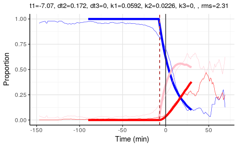

```r
pars <- chr.scr$pars
free <- c("k1", "k2", "t1", "dt2")
chr.smc.2 <- cacheData("fit_SMC2_n10000_k1_k2_t1_dt2", fitChr, echr.smc, pars, free, nsim=10000, ntry=50, ncores=6, binDir=binDir)
plotTimelines(chr.smc.2, expdata = echr.smc, withpars=TRUE)
```

# 14/08/2017

SMC2 with parameters fixed from NCAPD.

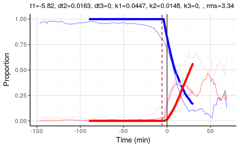

```r
pars$k1 <- chr.d3.2$pars$k1
pars$t1 <- chr.d3.2$pars$t1
pars$k2 <- chr.d2.2$pars$k2
pars$dt2 <- chr.d2.2$pars$dt2
chr.smc.fixed <- chr.d3
chr.smc.fixed$pars <- pars
plotTimelines(chr.smc.fixed, expdata = echr.smc, withpars=TRUE)
```

# 16/08/2017

Nice discussion with Tim Newman. A few new ideas:

- replace $t_1$ with the exponential “decay” (going back in time) to smooth the cusp in the model; there will be still one parameter here, exponential factor roughly about$1/t_1$
- compare pairs coming from the same cell - John will send me the info - see if same-cell pairs are more corerlated than random
- try aligning cells independnetly from the nuclear membrane breakdown, based on correlation
- think of other properties, e.g. in random walk there is “persistance”, the fraction of drunks that do not fall over the cliff